# real_estate_project

DESCRIPTION Problem Statement A banking institution requires actionable insights into mortgage-backed securities, geographic business investment, and real estate analysis. The mortgage bank would like to identify potential monthly mortgage expenses for each region based on monthly family income and rental of the real estate. A statistical model needs to be created to predict the potential demand in dollars amount of loan for each of the region in the USA. Also, there is a need to create a dashboard which would refresh periodically post data retrieval from the agencies. The dashboard must demonstrate relationships and trends for the key metrics as follows: number of loans, average rental income, monthly mortgage and owner’s cost, family income vs mortgage cost comparison across different regions. The metrics described here do not limit the dashboard to these few. Dataset Description Variables Description Second mortgage Households with a second mortgage statistics Home equity Households with a home equity loan statistics Debt Households with any type of debt statistics Mortgage Costs Statistics regarding mortgage payments, home equity loans, utilities, and property taxes Home Owner Costs Sum of utilities, and property taxes statistics Gross Rent Contract rent plus the estimated average monthly cost of utility features High school Graduation High school graduation statistics Population Demographics Population demographics statistics Age Demographics Age demographic statistics Household Income Total income of people residing in the household Family Income Total income of people related to the householderProject Task: Week 1 Data Import and Preparation: Import data. Figure out the primary key and look for the requirement of indexing. Gauge the fill rate of the variables and devise plans for missing value treatment. Please explain explicitly the reason for the treatment chosen for each variable.

```python
import pandas as pd
pd.set_option('display.max_columns', 100)
pd.set_option('display.max_rows', 100)
import numpy as np
import matplotlib.pyplot as plt
import seaborn as sns
import warnings
warnings.filterwarnings('ignore')
```

```python
train_data=pd.read_csv('train.csv')
test_data=pd.read_csv('test.csv')
```

```python
train_data.head(2)
```

|  | UID | BLOCKID | SUMLEVEL | COUNTYID | STATEID | state | state_ab | city | place | type | primary | zip_code | area_code | lat | lng | ALand | AWater | pop | male_pop | female_pop | rent_mean | rent_median | rent_stdev | rent_sample_weight | rent_samples | rent_gt_10 | rent_gt_15 | rent_gt_20 | rent_gt_25 | … |
| --- | --- | --- | --- | --- | --- | --- | --- | --- | --- | --- | --- | --- | --- | --- | --- | --- | --- | --- | --- | --- | --- | --- | --- | --- | --- | --- | --- | --- | --- | --- |
| 0 | 267822 | NaN | 140 | 53 | 36 | New York | NY | Hamilton | Hamilton | City | tract | 13346 | 315 | 42.840812 | -75.501524 | 202183361.0 | 1699120 | 5230 | 2612 | 2618 | 769.38638 | 784.0 | 232.63967 | 272.34441 | 362.0 | 0.86761 | 0.79155 | 0.59155 | 0.45634 | … |
| 1 | 246444 | NaN | 140 | 141 | 18 | Indiana | IN | South Bend | Roseland | City | tract | 46616 | 574 | 41.701441 | -86.266614 | 1560828.0 | 100363 | 2633 | 1349 | 1284 | 804.87924 | 848.0 | 253.46747 | 312.58622 | 513.0 | 0.97410 | 0.93227 | 0.69920 | 0.69920 | … |

```python
test_data.head(2)
```

|  | UID | BLOCKID | SUMLEVEL | COUNTYID | STATEID | state | state_ab | city | place | type | primary | zip_code | area_code | lat | lng | ALand | AWater | pop | male_pop | female_pop | rent_mean | rent_median | rent_stdev | rent_sample_weight | rent_samples | rent_gt_10 | rent_gt_15 | rent_gt_20 | rent_gt_25 | … |
| --- | --- | --- | --- | --- | --- | --- | --- | --- | --- | --- | --- | --- | --- | --- | --- | --- | --- | --- | --- | --- | --- | --- | --- | --- | --- | --- | --- | --- | --- | --- |
| 0 | 255504 | NaN | 140 | 163 | 26 | Michigan | MI | Detroit | Dearborn Heights City | CDP | tract | 48239 | 313 | 42.346422 | -83.252823 | 2711280 | 39555 | 3417 | 1479 | 1938 | 858.57169 | 859.0 | 232.39082 | 276.07497 | 424.0 | 1.0 | 0.95696 | 0.85316 | 0.85316 | … |
| 1 | 252676 | NaN | 140 | 1 | 23 | Maine | ME | Auburn | Auburn City | City | tract | 4210 | 207 | 44.100724 | -70.257832 | 14778785 | 2705204 | 3796 | 1846 | 1950 | 832.68625 | 750.0 | 267.22342 | 183.32299 | 245.0 | 1.0 | 1.00000 | 0.86611 | 0.67364 | … |

```python
print(train_data.shape)
print(test_data.shape)
```

```
(27321, 80)
(11709, 80)
```

```python
train_var=train_data.var().to_frame().reset_index()
train_var[train_var[0]==0]
```

|  | index | 0 |
| --- | --- | --- |
| 2 | SUMLEVEL | 0.0 |

```python
test_var=test_data.var().to_frame().reset_index()
test_var[test_var[0]==0]
```

|  | index | 0 |
| --- | --- | --- |
| 2 | SUMLEVEL | 0.0 |

As the variance of SUMLEVEL column is zero, we can drop this column

```python
train_data.nunique().to_frame()[train_data.nunique().to_frame()[0]==0]
```

|  | 0 |
| --- | --- |
| BLOCKID | 0 |

```python
test_data.nunique().to_frame()[test_data.nunique().to_frame()[0]==0]
```

|  | 0 |
| --- | --- |
| BLOCKID | 0 |

As the no. of unique values for BLOCKID column is zero, we can drop this column

```python
df_merged=train_data.append(test_data,ignore_index=True)
df_merged.head(2)
```

|  | UID | BLOCKID | SUMLEVEL | COUNTYID | STATEID | state | state_ab | city | place | type | primary | zip_code | area_code | lat | lng | ALand | AWater | pop | male_pop | female_pop | rent_mean | rent_median | rent_stdev | rent_sample_weight | rent_samples | rent_gt_10 | rent_gt_15 | rent_gt_20 | rent_gt_25 | … |
| --- | --- | --- | --- | --- | --- | --- | --- | --- | --- | --- | --- | --- | --- | --- | --- | --- | --- | --- | --- | --- | --- | --- | --- | --- | --- | --- | --- | --- | --- | --- |
| 0 | 267822 | NaN | 140 | 53 | 36 | New York | NY | Hamilton | Hamilton | City | tract | 13346 | 315 | 42.840812 | -75.501524 | 202183361.0 | 1699120 | 5230 | 2612 | 2618 | 769.38638 | 784.0 | 232.63967 | 272.34441 | 362.0 | 0.86761 | 0.79155 | 0.59155 | 0.45634 | … |
| 1 | 246444 | NaN | 140 | 141 | 18 | Indiana | IN | South Bend | Roseland | City | tract | 46616 | 574 | 41.701441 | -86.266614 | 1560828.0 | 100363 | 2633 | 1349 | 1284 | 804.87924 | 848.0 | 253.46747 | 312.58622 | 513.0 | 0.97410 | 0.93227 | 0.69920 | 0.69920 | … |

```python
df_merged.shape
```

```
(39030, 80)
```

```python
df_merged.drop(columns=['SUMLEVEL','BLOCKID'],axis=1,inplace=True)
```

```python
df_merged.shape
```

```
(39030, 78)
```

```python
df_merged.duplicated().sum()
```

```
315
```

```python
df_merged.drop_duplicates(inplace=True)
```

```python
df_merged.shape
```

```
(38715, 78)
```

```python
df_merged.nunique()
```

```
UID                            38715
COUNTYID                         310
STATEID                           52
state                             52
state_ab                          52
city                            8172
place                          11856
type                               6
primary                            1
zip_code                       15098
area_code                        275
lat                            38710
lng                            38713
ALand                          38665
AWater                         23212
pop                             8319
male_pop                        4886
female_pop                      4986
rent_mean                      38220
rent_median                     2517
rent_stdev                     38205
rent_sample_weight             37997
rent_samples                    2333
rent_gt_10                      9972
rent_gt_15                     17136
rent_gt_20                     21017
rent_gt_25                     22548
rent_gt_30                     22954
rent_gt_35                     22704
rent_gt_40                     22271
rent_gt_50                     20971
universe_samples                2368
used_samples                    2276
hi_mean                        38415
hi_median                      30964
hi_stdev                       38410
hi_sample_weight               38424
hi_samples                      3740
family_mean                    38387
family_median                  31867
```

[output cut: 24 more lines]

```
male_age_median                  717
male_age_stdev                 37342
male_age_sample_weight         38513
male_age_samples                4885
female_age_mean                38060
female_age_median                694
female_age_stdev               37312
female_age_sample_weight       38488
female_age_samples              4985
pct_own                        29602
married                        26133
married_snp                    11637
separated                       6893
divorced                       15838
dtype: int64
```

we can observe that the UID column has the same no. of unique values as the no. of rows of dataset, so, we can take the UID column as the primary key.

```python
df_sorted=df_merged.sort_values(by=['UID']).set_index('UID')
df_sorted.head(2)
```

| UID | COUNTYID | STATEID | state | state_ab | city | place | type | primary | zip_code | area_code | lat | lng | ALand | AWater | pop | male_pop | female_pop | rent_mean | rent_median | rent_stdev | rent_sample_weight | rent_samples | rent_gt_10 | rent_gt_15 | rent_gt_20 | rent_gt_25 | rent_gt_30 | rent_gt_35 | rent_gt_40 | … |
| --- | --- | --- | --- | --- | --- | --- | --- | --- | --- | --- | --- | --- | --- | --- | --- | --- | --- | --- | --- | --- | --- | --- | --- | --- | --- | --- | --- | --- | --- | --- |
| 220336 | 16 | 2 | Alaska | AK | Unalaska | Unalaska City | City | tract | 99685 | 907 | 53.621091 | -166.770979 | 2.823180e+09 | 3101986247 | 4619 | 2725 | 1894 | 1366.24657 | 1405.0 | 650.16380 | 131.50967 | 372.0 | 0.85676 | 0.65676 | 0.47838 | 0.35405 | 0.28108 | 0.21081 | 0.15135 | … |
| 220342 | 20 | 2 | Alaska | AK | Eagle River | Anchorage | City | tract | 99577 | 907 | 61.174250 | -149.284329 | 5.092349e+08 | 1859309 | 3727 | 1780 | 1947 | 2347.69441 | 2351.0 | 382.73576 | 4.32064 | 44.0 | 0.79545 | 0.56818 | 0.56818 | 0.45455 | 0.20455 | 0.20455 | 0.20455 | … |

```python
df_sorted.shape
```

```
(38715, 77)
```

```python
df_sorted.isnull().sum()
```

```
COUNTYID                         0
STATEID                          0
state                            0
state_ab                         0
city                             0
place                            0
type                             0
primary                          0
zip_code                         0
area_code                        0
lat                              0
lng                              0
ALand                            0
AWater                           0
pop                              0
male_pop                         0
female_pop                       0
rent_mean                      320
rent_median                    320
rent_stdev                     320
rent_sample_weight             320
rent_samples                   320
rent_gt_10                     321
rent_gt_15                     321
rent_gt_20                     321
rent_gt_25                     321
rent_gt_30                     321
rent_gt_35                     321
rent_gt_40                     321
rent_gt_50                     321
universe_samples                 0
used_samples                     0
hi_mean                        271
hi_median                      271
hi_stdev                       271
hi_sample_weight               271
hi_samples                     271
family_mean                    303
family_median                  303
family_stdev                   303
```

[output cut: 23 more lines]

```
male_age_median                194
male_age_stdev                 194
male_age_sample_weight         194
male_age_samples               194
female_age_mean                211
female_age_median              211
female_age_stdev               211
female_age_sample_weight       211
female_age_samples             211
pct_own                        271
married                        196
married_snp                    196
separated                      196
divorced                       196
dtype: int64
```

```python
missing_value_columns=df_sorted.isnull().sum()[df_sorted.isnull().sum()>0].to_frame().reset_index()['index'].values
missing_value_columns
```

```
array(['rent_mean', 'rent_median', 'rent_stdev', 'rent_sample_weight',
       'rent_samples', 'rent_gt_10', 'rent_gt_15', 'rent_gt_20',
       'rent_gt_25', 'rent_gt_30', 'rent_gt_35', 'rent_gt_40',
       'rent_gt_50', 'hi_mean', 'hi_median', 'hi_stdev',
       'hi_sample_weight', 'hi_samples', 'family_mean', 'family_median',
       'family_stdev', 'family_sample_weight', 'family_samples',
       'hc_mortgage_mean', 'hc_mortgage_median', 'hc_mortgage_stdev',
       'hc_mortgage_sample_weight', 'hc_mortgage_samples', 'hc_mean',
       'hc_median', 'hc_stdev', 'hc_samples', 'hc_sample_weight',
       'home_equity_second_mortgage', 'second_mortgage', 'home_equity',
       'debt', 'second_mortgage_cdf', 'home_equity_cdf', 'debt_cdf',
       'hs_degree', 'hs_degree_male', 'hs_degree_female', 'male_age_mean',
       'male_age_median', 'male_age_stdev', 'male_age_sample_weight',
       'male_age_samples', 'female_age_mean', 'female_age_median',
       'female_age_stdev', 'female_age_sample_weight',
       'female_age_samples', 'pct_own', 'married', 'married_snp',
       'separated', 'divorced'], dtype=object)
```

```python
for i in missing_value_columns:
    df_sorted[i].replace(to_replace=np.nan,value=df_sorted[df_sorted[i]!=0][i].median(),inplace=True)
```

```python
df_sorted.isnull().sum()
```

```
COUNTYID                       0
STATEID                        0
state                          0
state_ab                       0
city                           0
place                          0
type                           0
primary                        0
zip_code                       0
area_code                      0
lat                            0
lng                            0
ALand                          0
AWater                         0
pop                            0
male_pop                       0
female_pop                     0
rent_mean                      0
rent_median                    0
rent_stdev                     0
rent_sample_weight             0
rent_samples                   0
rent_gt_10                     0
rent_gt_15                     0
rent_gt_20                     0
rent_gt_25                     0
rent_gt_30                     0
rent_gt_35                     0
rent_gt_40                     0
rent_gt_50                     0
universe_samples               0
used_samples                   0
hi_mean                        0
hi_median                      0
hi_stdev                       0
hi_sample_weight               0
hi_samples                     0
family_mean                    0
family_median                  0
family_stdev                   0
```

[output cut: 23 more lines]

```
male_age_median                0
male_age_stdev                 0
male_age_sample_weight         0
male_age_samples               0
female_age_mean                0
female_age_median              0
female_age_stdev               0
female_age_sample_weight       0
female_age_samples             0
pct_own                        0
married                        0
married_snp                    0
separated                      0
divorced                       0
dtype: int64
```

As presence of outliers are there so we treated the missing values with the median of non_null values

Exploratory Data Analysis (EDA): 4.Perform debt analysis. You may take the following steps: a) Explore the top 2,500 locations where the percentage of households with a second mortgage is the highest and percent ownership is above 10 percent. Visualize using geo-map. You may keep the upper limit for the percent of households with a second mortgage to 50 percent b) Use the following bad debt equation: Bad Debt = P (Second Mortgage ∩ Home Equity Loan) Bad Debt = second_mortgage + home_equity - home_equity_second_mortgage c) Create pie charts to show overall debt and bad debt d) Create Box and whisker plot and analyze the distribution for 2nd mortgage, home equity, good debt, and bad debt for different cities e) Create a collated income distribution chart for family income, house hold income, and remaining income

```python
df_sorted.head(2)
```

| UID | COUNTYID | STATEID | state | state_ab | city | place | type | primary | zip_code | area_code | lat | lng | ALand | AWater | pop | male_pop | female_pop | rent_mean | rent_median | rent_stdev | rent_sample_weight | rent_samples | rent_gt_10 | rent_gt_15 | rent_gt_20 | rent_gt_25 | rent_gt_30 | rent_gt_35 | rent_gt_40 | … |
| --- | --- | --- | --- | --- | --- | --- | --- | --- | --- | --- | --- | --- | --- | --- | --- | --- | --- | --- | --- | --- | --- | --- | --- | --- | --- | --- | --- | --- | --- | --- |
| 220336 | 16 | 2 | Alaska | AK | Unalaska | Unalaska City | City | tract | 99685 | 907 | 53.621091 | -166.770979 | 2.823180e+09 | 3101986247 | 4619 | 2725 | 1894 | 1366.24657 | 1405.0 | 650.16380 | 131.50967 | 372.0 | 0.85676 | 0.65676 | 0.47838 | 0.35405 | 0.28108 | 0.21081 | 0.15135 | … |
| 220342 | 20 | 2 | Alaska | AK | Eagle River | Anchorage | City | tract | 99577 | 907 | 61.174250 | -149.284329 | 5.092349e+08 | 1859309 | 3727 | 1780 | 1947 | 2347.69441 | 2351.0 | 382.73576 | 4.32064 | 44.0 | 0.79545 | 0.56818 | 0.56818 | 0.45455 | 0.20455 | 0.20455 | 0.20455 | … |

```python
top_2500_loc=df_sorted[(df_sorted['second_mortgage'] <= 0.50) & (df_sorted['pct_own'] >= 0.10)].sort_values(by=['second_mortgage'],ascending=False).iloc[0:2500,0:12]
```

```python
top_2500_loc.shape
```

```
(2500, 12)
```

```python
top_2500_loc
```

| UID | COUNTYID | STATEID | state | state_ab | city | place | type | primary | zip_code | area_code | lat | lng |
| --- | --- | --- | --- | --- | --- | --- | --- | --- | --- | --- | --- | --- |
| 289712 | 147 | 51 | Virginia | VA | Farmville | Farmville | Town | tract | 23901 | 434 | 37.297357 | -78.396452 |
| 251185 | 27 | 25 | Massachusetts | MA | Worcester | Worcester City | City | tract | 1610 | 508 | 42.254262 | -71.800347 |
| 274394 | 109 | 40 | Oklahoma | OK | Edmond | Edmond City | CDP | tract | 73003 | 405 | 35.655695 | -97.471535 |
| 269323 | 81 | 36 | New York | NY | Corona | Harbor Hills | City | tract | 11368 | 718 | 40.751809 | -73.853582 |
| 251324 | 3 | 24 | Maryland | MD | Glen Burnie | Glen Burnie | CDP | tract | 21061 | 410 | 39.127273 | -76.635265 |
| ... | ... | ... | ... | ... | ... | ... | ... | ... | ... | ... | ... | ... |
| 237752 | 101 | 12 | Florida | FL | Lutz | Land O' Lakes | City | tract | 33559 | 813 | 28.180613 | -82.411130 |
| 227787 | 59 | 6 | California | CA | Placentia | Placentia City | City | tract | 92870 | 714 | 33.884298 | -117.835058 |
| 263359 | 13 | 34 | New Jersey | NJ | Newark | East Newark | City | tract | 7102 | 973 | 40.755603 | -74.169575 |
| 230967 | 85 | 6 | California | CA | Milpitas | Milpitas City | City | tract | 95035 | 408 | 37.421551 | -121.896491 |
| 246862 | 45 | 20 | Kansas | KS | Lawrence | Lawrence City | City | tract | 66046 | 785 | 38.930997 | -95.197281 |

2500 rows × 12 columns

```python
df_sorted['bad_debt']=df_sorted.second_mortgage + df_sorted.home_equity - df_sorted.home_equity_second_mortgage
```

```python
df_sorted.iloc[0:5,-1:]
```

| UID | bad_debt |
| --- | --- |
| 220336 | 0.03756 |
| 220342 | 0.09876 |
| 220343 | 0.00000 |
| 220345 | 0.04469 |
| 220347 | 0.08514 |

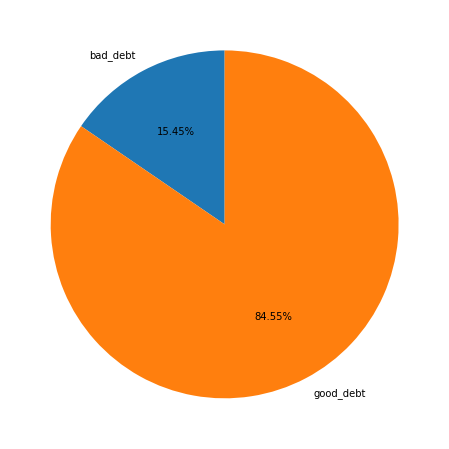

```python
plt.figure(figsize=(8,8))
plt.pie(np.array([np.median(df_sorted.bad_debt),np.median(df_sorted.debt)-np.median(df_sorted.bad_debt)]),labels=['bad_debt','good_debt'],startangle=90,autopct='%1.2f%%')
plt.show()
plt.tight_layout()
```

```python
df_sorted.city.nunique()
```

```
8172
```

```python
df_sorted['good_debt']=df_sorted.debt-df_sorted.bad_debt
```

```python
df_sorted.iloc[0:5,-1:]
```

| UID | good_debt |
| --- | --- |
| 220336 | 0.69014 |
| 220342 | 0.65813 |
| 220343 | 0.00000 |
| 220345 | 0.73743 |
| 220347 | 0.58732 |

```python
bp1=df_sorted.groupby(by=['city'])['second_mortgage'].median().values
bp1
```

```
array([0.03775 , 0.018555, 0.0072  , ..., 0.00357 , 0.05802 , 0.      ])
```

```python
bp2=df_sorted.groupby(by=['city'])['home_equity'].median().values
bp2
```

```
array([0.05167, 0.0873 , 0.02594, ..., 0.02262, 0.18946, 0.     ])
```

```python
bp3=df_sorted.groupby(by=['city'])['good_debt'].median().values
bp3
```

```
array([0.42663  , 0.5560025, 0.41066  , ..., 0.27262  , 0.42392  ,
       0.25743  ])
```

```python
bp4=df_sorted.groupby(by=['city'])['bad_debt'].median().values
bp4
```

```
array([0.05167, 0.0873 , 0.03314, ..., 0.02262, 0.19301, 0.     ])
```

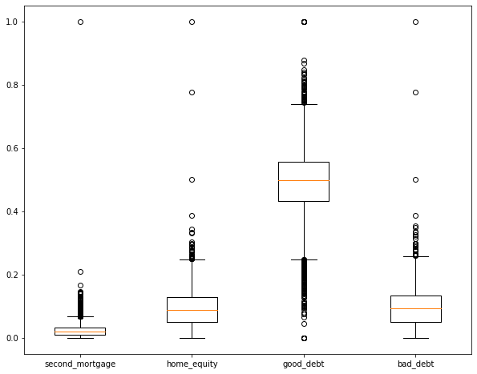

```python
plt.figure(figsize=(10,8))
plt.boxplot((bp1,bp2,bp3,bp4))
plt.xticks([1,2,3,4],['second_mortgage','home_equity','good_debt','bad_debt'])
plt.show()
plt.tight_layout()
```

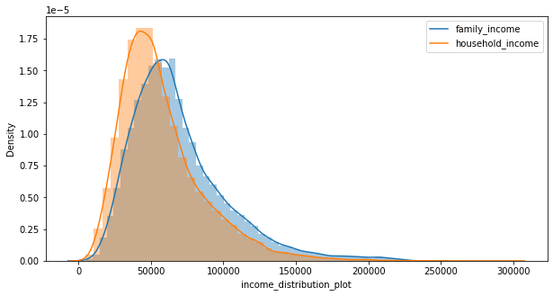

```python
plt.figure(figsize=(10,5))
sns.distplot(df_sorted.family_median)
sns.distplot(df_sorted.hi_median)
plt.xlabel('income_distribution_plot')
plt.legend(['family_income','household_income'])
plt.show()
plt.tight_layout()
```

Project Task: Week 2 Exploratory Data Analysis (EDA): 1. Perform EDA and come out with insights into population density and age. You may have to derive new fields (make sure to weight averages for accurate measurements): a) Use pop and ALand variables to create a new field called population density b) Use male_age_median, female_age_median, male_pop, and female_pop to create a new field called median age c) Visualize the findings using appropriate chart type

```python
df_sorted.head()
```

| UID | COUNTYID | STATEID | state | state_ab | city | place | type | primary | zip_code | area_code | lat | lng | ALand | AWater | pop | male_pop | female_pop | rent_mean | rent_median | rent_stdev | rent_sample_weight | rent_samples | rent_gt_10 | rent_gt_15 | rent_gt_20 | rent_gt_25 | rent_gt_30 | rent_gt_35 | rent_gt_40 | … |
| --- | --- | --- | --- | --- | --- | --- | --- | --- | --- | --- | --- | --- | --- | --- | --- | --- | --- | --- | --- | --- | --- | --- | --- | --- | --- | --- | --- | --- | --- | --- |
| 220336 | 16 | 2 | Alaska | AK | Unalaska | Unalaska City | City | tract | 99685 | 907 | 53.621091 | -166.770979 | 2.823180e+09 | 3101986247 | 4619 | 2725 | 1894 | 1366.24657 | 1405.0 | 650.16380 | 131.50967 | 372.0 | 0.85676 | 0.65676 | 0.47838 | 0.35405 | 0.28108 | 0.21081 | 0.15135 | … |
| 220342 | 20 | 2 | Alaska | AK | Eagle River | Anchorage | City | tract | 99577 | 907 | 61.174250 | -149.284329 | 5.092349e+08 | 1859309 | 3727 | 1780 | 1947 | 2347.69441 | 2351.0 | 382.73576 | 4.32064 | 44.0 | 0.79545 | 0.56818 | 0.56818 | 0.45455 | 0.20455 | 0.20455 | 0.20455 | … |
| 220343 | 20 | 2 | Alaska | AK | Jber | Anchorage | City | tract | 99505 | 907 | 61.284745 | -149.653973 | 2.705930e+08 | 66534601 | 8736 | 5166 | 3570 | 2071.30766 | 2089.0 | 442.89099 | 195.07816 | 1749.0 | 0.99469 | 0.97403 | 0.92680 | 0.89020 | 0.73022 | 0.62574 | 0.54368 | … |
| 220345 | 20 | 2 | Alaska | AK | Anchorage | Point Mackenzie | City | tract | 99501 | 907 | 61.229560 | -149.893037 | 2.371512e+06 | 9966854 | 1941 | 892 | 1049 | 943.79086 | 914.0 | 308.34101 | 396.51652 | 720.0 | 0.97046 | 0.81435 | 0.67651 | 0.58509 | 0.39381 | 0.32208 | 0.27286 | … |
| 220347 | 20 | 2 | Alaska | AK | Anchorage | Anchorage | City | tract | 99504 | 907 | 61.217082 | -149.767214 | 1.979230e+06 | 0 | 5981 | 3076 | 2905 | 1372.84472 | 1222.0 | 541.82102 | 251.53249 | 878.0 | 0.97836 | 0.90319 | 0.80068 | 0.66856 | 0.45900 | 0.34738 | 0.24829 | … |

```python
df_sorted['pop_density']=df_sorted['pop']/df_sorted['ALand']
```

```python
df_sorted.iloc[0:5,-1:]
```

| UID | pop_density |
| --- | --- |
| 220336 | 0.000002 |
| 220342 | 0.000007 |
| 220343 | 0.000032 |
| 220345 | 0.000818 |
| 220347 | 0.003022 |

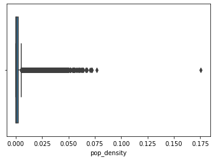

```python
sns.boxplot(df_sorted.pop_density)
```

```python
df_sorted['median_age']=((df_sorted['male_age_median'] * df_sorted['male_pop'])+(df_sorted['female_age_median']*df_sorted['female_pop']))/(df_sorted['male_pop']+df_sorted['female_pop'])
```

```python
df_sorted.iloc[0:5,-1:]
```

| UID | median_age |
| --- | --- |
| 220336 | 36.243001 |
| 220342 | 39.507468 |
| 220343 | 22.624601 |
| 220345 | 34.000000 |
| 220347 | 30.935701 |

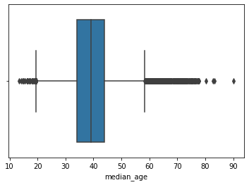

```python
sns.boxplot(df_sorted.median_age)
```

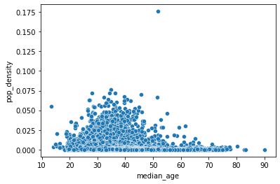

```python
sns.scatterplot(x=df_sorted['median_age'],y=df_sorted['pop_density'])
```

2. Create bins for population into a new variable by selecting appropriate class interval so that the number of categories don’t exceed 5 for the ease of analysis. a) Analyze the married, separated, and divorced population for these population brackets b) Visualize using appropriate chart type 3. Please detail your observations for rent as a percentage of income at an overall level, and for different states. 4. Perform correlation analysis for all the relevant variables by creating a heatmap. Describe your findings.

```python
bin_range=[]
for population in df_sorted['pop'].values:
    if (population>=0 and population<=1000):
        bin_range.append('0-1k')
    elif (population>=1000 and population<=2000):
        bin_range.append('1k-2k')
    elif (population>=2000 and population<=3000):
        bin_range.append('2k-3k')
    elif (population>=3000 and population<=4000):
        bin_range.append('3k-4k')
    else:
        bin_range.append('>4k')
```

```python
df_sorted['bins']=bin_range
```

```python
df_sorted.iloc[:5,-1:]
```

| UID | bins |
| --- | --- |
| 220336 | >4k |
| 220342 | 3k-4k |
| 220343 | >4k |
| 220345 | 1k-2k |
| 220347 | >4k |

```python
df_sorted.groupby('bins')[['married', 'separated','divorced']].sum()
```

| bins | married | separated | divorced |
| --- | --- | --- | --- |
| 0-1k | 253.67480 | 14.59686 | 61.06632 |
| 1k-2k | 1402.32403 | 71.89912 | 348.20461 |
| 2k-3k | 3284.66443 | 136.47545 | 736.88947 |
| 3k-4k | 4235.27192 | 160.30269 | 857.50611 |
| >4k | 10521.72846 | 356.51772 | 1871.17144 |

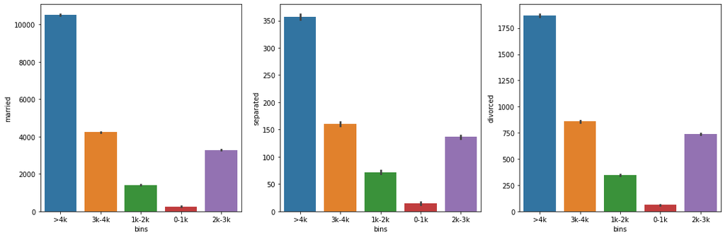

```python
plt.figure(figsize=(15,5))
for i,j in zip(range(1,4),['married', 'separated','divorced']):
    plt.subplot(1,3,i)
    sns.barplot(x="bins",y=j,data=df_sorted,estimator=sum)
    plt.tight_layout()
```

```python
df_sorted.head(2)
```

| UID | COUNTYID | STATEID | state | state_ab | city | place | type | primary | zip_code | area_code | lat | lng | ALand | AWater | pop | male_pop | female_pop | rent_mean | rent_median | rent_stdev | rent_sample_weight | rent_samples | rent_gt_10 | rent_gt_15 | rent_gt_20 | rent_gt_25 | rent_gt_30 | rent_gt_35 | rent_gt_40 | … |
| --- | --- | --- | --- | --- | --- | --- | --- | --- | --- | --- | --- | --- | --- | --- | --- | --- | --- | --- | --- | --- | --- | --- | --- | --- | --- | --- | --- | --- | --- | --- |
| 220336 | 16 | 2 | Alaska | AK | Unalaska | Unalaska City | City | tract | 99685 | 907 | 53.621091 | -166.770979 | 2.823180e+09 | 3101986247 | 4619 | 2725 | 1894 | 1366.24657 | 1405.0 | 650.16380 | 131.50967 | 372.0 | 0.85676 | 0.65676 | 0.47838 | 0.35405 | 0.28108 | 0.21081 | 0.15135 | … |
| 220342 | 20 | 2 | Alaska | AK | Eagle River | Anchorage | City | tract | 99577 | 907 | 61.174250 | -149.284329 | 5.092349e+08 | 1859309 | 3727 | 1780 | 1947 | 2347.69441 | 2351.0 | 382.73576 | 4.32064 | 44.0 | 0.79545 | 0.56818 | 0.56818 | 0.45455 | 0.20455 | 0.20455 | 0.20455 | … |

```python
df_sorted.groupby('state')[['rent_gt_10','rent_gt_15', 'rent_gt_20', 'rent_gt_25', 'rent_gt_30', 'rent_gt_35','rent_gt_40', 'rent_gt_50']].median()
```

| state | rent_gt_10 | rent_gt_15 | rent_gt_20 | rent_gt_25 | rent_gt_30 | rent_gt_35 | rent_gt_40 | rent_gt_50 |
| --- | --- | --- | --- | --- | --- | --- | --- | --- |
| Alabama | 0.971220 | 0.863640 | 0.733345 | 0.617945 | 0.506040 | 0.416800 | 0.347755 | 0.250525 |
| Alaska | 0.959720 | 0.842110 | 0.676510 | 0.542980 | 0.416580 | 0.330880 | 0.257400 | 0.165640 |
| Arizona | 0.986060 | 0.888555 | 0.754370 | 0.616905 | 0.498345 | 0.403225 | 0.326315 | 0.234495 |
| Arkansas | 0.973270 | 0.865050 | 0.728680 | 0.596410 | 0.475000 | 0.383620 | 0.318810 | 0.218580 |
| California | 0.985080 | 0.920915 | 0.815775 | 0.692250 | 0.569720 | 0.470645 | 0.393870 | 0.285555 |
| Colorado | 0.981230 | 0.896550 | 0.762060 | 0.619490 | 0.500000 | 0.387970 | 0.322150 | 0.222820 |
| Connecticut | 0.980240 | 0.900120 | 0.779100 | 0.653440 | 0.516630 | 0.414430 | 0.355330 | 0.246650 |
| Delaware | 0.972770 | 0.888710 | 0.764420 | 0.624840 | 0.495270 | 0.408420 | 0.340360 | 0.234290 |
| District of Columbia | 0.961975 | 0.863560 | 0.738670 | 0.615535 | 0.501020 | 0.398270 | 0.331420 | 0.252465 |
| Florida | 0.993580 | 0.925790 | 0.821170 | 0.687500 | 0.571430 | 0.471755 | 0.396165 | 0.277755 |
| Georgia | 0.982140 | 0.895420 | 0.763780 | 0.636290 | 0.523260 | 0.430260 | 0.359690 | 0.261400 |
| Hawaii | 0.984360 | 0.902265 | 0.798635 | 0.668970 | 0.559465 | 0.448095 | 0.374615 | 0.268965 |
| Idaho | 0.963110 | 0.861650 | 0.720050 | 0.585170 | 0.477400 | 0.360725 | 0.310085 | 0.201265 |
| Illinois | 0.974620 | 0.884240 | 0.745220 | 0.611940 | 0.486340 | 0.398110 | 0.332110 | 0.245400 |
| Indiana | 0.974650 | 0.872530 | 0.731615 | 0.581365 | 0.467835 | 0.375730 | 0.312760 | 0.226055 |
| Iowa | 0.945810 | 0.818870 | 0.657750 | 0.515790 | 0.407840 | 0.320430 | 0.268660 | 0.185290 |
| Kansas | 0.965015 | 0.850950 | 0.697060 | 0.562180 | 0.424270 | 0.333755 | 0.266855 | 0.188195 |
| Kentucky | 0.964350 | 0.859500 | 0.720430 | 0.591550 | 0.479320 | 0.383160 | 0.319090 | 0.231740 |
| Louisiana | 0.967690 | 0.866940 | 0.750000 | 0.630770 | 0.521280 | 0.432680 | 0.373430 | 0.272980 |
| Maine | 0.971835 | 0.886820 | 0.754390 | 0.646405 | 0.503645 | 0.403600 | 0.329450 | 0.243295 |
| Maryland | 0.986750 | 0.905660 | 0.777160 | 0.631510 | 0.508720 | 0.409720 | 0.333330 | 0.239800 |
| Massachusetts | 0.972710 | 0.888500 | 0.757600 | 0.614480 | 0.487800 | 0.389960 | 0.315700 | 0.232880 |
| Michigan | 0.981440 | 0.894030 | 0.769230 | 0.648475 | 0.523400 | 0.429805 | 0.361880 | 0.264710 |
| Minnesota | 0.971930 | 0.880385 | 0.740315 | 0.594070 | 0.457800 | 0.361220 | 0.293200 | 0.208555 |
| Mississippi | 0.974770 | 0.883250 | 0.763890 | 0.633510 | 0.538460 | 0.445160 | 0.369490 | 0.264410 |
| Missouri | 0.971290 | 0.866340 | 0.726500 | 0.596210 | 0.469390 | 0.370650 | 0.307090 | 0.222510 |
| Montana | 0.949545 | 0.830610 | 0.677465 | 0.549660 | 0.423515 | 0.353585 | 0.275905 | 0.190780 |
| Nebraska | 0.957155 | 0.845575 | 0.685725 | 0.518015 | 0.401730 | 0.320640 | 0.262985 | 0.176285 |
| Nevada | 0.979920 | 0.896770 | 0.761560 | 0.624560 | 0.490760 | 0.408380 | 0.323690 | 0.233580 |
| New Hampshire | 0.984920 | 0.903110 | 0.758180 | 0.622010 | 0.479310 | 0.390090 | 0.306550 | 0.220610 |
| New Jersey | 0.982140 | 0.900570 | 0.787675 | 0.657035 | 0.534930 | 0.440900 | 0.365905 | 0.267505 |
| New Mexico | 0.970970 | 0.865790 | 0.736840 | 0.617280 | 0.505230 | 0.407080 | 0.338310 | 0.246070 |
| New York | 0.974700 | 0.888500 | 0.773030 | 0.650730 | 0.535475 | 0.440915 | 0.373340 | 0.283000 |
| North Carolina | 0.978510 | 0.887990 | 0.753805 | 0.610975 | 0.500000 | 0.409450 | 0.338525 | 0.235905 |
| North Dakota | 0.898150 | 0.748875 | 0.575085 | 0.435060 | 0.348845 | 0.262010 | 0.208535 | 0.153965 |
| Ohio | 0.969335 | 0.868810 | 0.729915 | 0.597765 | 0.475845 | 0.390970 | 0.325420 | 0.229775 |
| Oklahoma | 0.950985 | 0.838855 | 0.689380 | 0.551845 | 0.443555 | 0.355895 | 0.292060 | 0.203745 |
| Oregon | 0.981990 | 0.903520 | 0.778620 | 0.644560 | 0.528340 | 0.441545 | 0.371710 | 0.275720 |
| Pennsylvania | 0.969970 | 0.868320 | 0.736375 | 0.603730 | 0.482010 | 0.392520 | 0.322365 | 0.231285 |
| Puerto Rico | 1.000000 | 0.913705 | 0.795300 | 0.684290 | 0.580845 | 0.475520 | 0.404895 | 0.316950 |
| Rhode Island | 0.978000 | 0.888270 | 0.760268 | 0.632400 | 0.501555 | 0.408570 | 0.337570 | 0.235640 |
| South Carolina | 0.981620 | 0.894590 | 0.759670 | 0.626400 | 0.512820 | 0.422510 | 0.353510 | 0.253010 |
| South Dakota | 0.932810 | 0.796790 | 0.631390 | 0.500000 | 0.372550 | 0.296610 | 0.242990 | 0.165180 |
| Tennessee | 0.977050 | 0.878785 | 0.747375 | 0.620125 | 0.490580 | 0.391150 | 0.320560 | 0.229280 |
| Texas | 0.972880 | 0.871940 | 0.732500 | 0.592230 | 0.473680 | 0.377780 | 0.308920 | 0.214170 |
| Utah | 0.980400 | 0.867025 | 0.729870 | 0.582435 | 0.457565 | 0.364710 | 0.288055 | 0.202120 |
| Vermont | 0.984910 | 0.907210 | 0.779645 | 0.637770 | 0.485200 | 0.412960 | 0.335785 | 0.229135 |
| Virginia | 0.984430 | 0.896420 | 0.761670 | 0.614720 | 0.490710 | 0.396230 | 0.321520 | 0.218750 |
| Washington | 0.979060 | 0.898790 | 0.767490 | 0.627720 | 0.494520 | 0.400800 | 0.325730 | 0.225420 |
| West Virginia | 0.945980 | 0.825910 | 0.703560 | 0.578810 | 0.465910 | 0.367820 | 0.303370 | 0.219840 |
| Wisconsin | 0.969120 | 0.859920 | 0.708900 | 0.573860 | 0.446850 | 0.355060 | 0.287540 | 0.204400 |
| Wyoming | 0.940280 | 0.818640 | 0.637210 | 0.476260 | 0.362190 | 0.268850 | 0.224430 | 0.145160 |

```python
df_sorted.shape
```

```
(38715, 82)
```

```python
df_sorted.corr()['hc_mortgage_mean'].to_frame()[df_sorted.corr()['hc_mortgage_mean'].to_frame()['hc_mortgage_mean']>=0.2].reset_index()['index'].values
```

```
array(['rent_mean', 'rent_median', 'rent_stdev', 'hi_mean', 'hi_median',
       'hi_stdev', 'family_mean', 'family_median', 'family_stdev',
       'hc_mortgage_mean', 'hc_mortgage_median', 'hc_mortgage_stdev',
       'hc_mean', 'hc_median', 'hc_stdev', 'home_equity', 'debt',
       'hs_degree', 'hs_degree_male', 'hs_degree_female', 'married',
       'bad_debt', 'good_debt', 'pop_density'], dtype=object)
```

```python
relevant_cols=['rent_mean', 'rent_median', 'rent_stdev', 'hi_mean', 'hi_median',
       'hi_stdev', 'family_mean', 'family_median', 'family_stdev',
       'hc_mortgage_median', 'hc_mortgage_stdev',
       'hc_mean', 'hc_median', 'hc_stdev', 'home_equity', 'debt',
       'hs_degree', 'hs_degree_male', 'hs_degree_female', 'married',
       'bad_debt', 'good_debt', 'pop_density','hc_mortgage_mean']
```

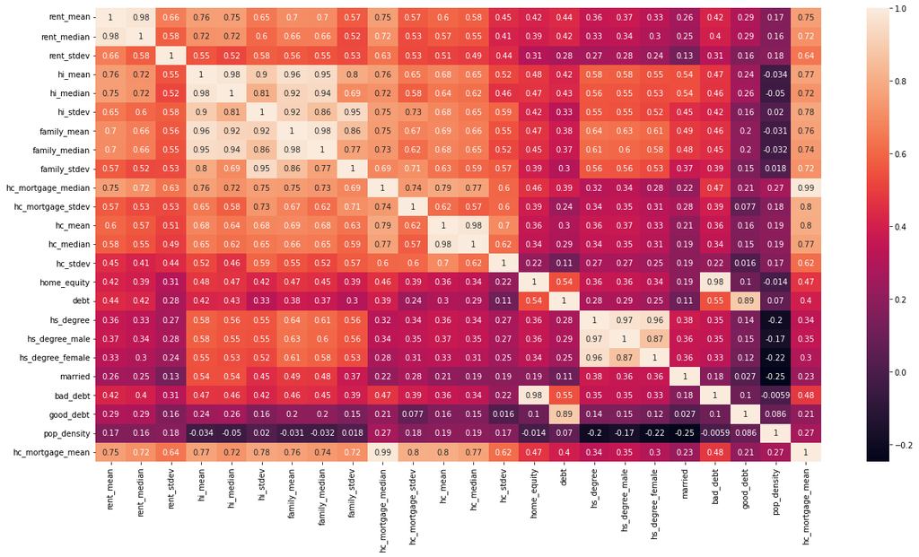

```python
plt.figure(figsize=(18,10))
sns.heatmap(df_sorted[relevant_cols].corr(),annot=True)
plt.tight_layout()
```

here, only the columns are taken whose correlation value is greater than 0.2 with the target variable. It is also observed that there are multicollinearity amongst the relevant variables.